# Stat Econ 2 Assignment 1

Victor Z. Nygaard

Last edited 28th of October 2021. Recompiled Feb 2024.

# Stat Econ 2 Assignment 1

## Exercise 1

We might note that we are dealing with an AR(1) process with slope $0.9$ and, assuming a central requirement, central $t$ - distributed noise with ten degrees of freedom. We simulate noise terms $Z_t$ for $t=1,\ldots,1000$

```r
set.seed(314)
desiredlag <- 20
phi <- 0.9
n <- 10^3
Z <- rt(df = 10, n=n)
```

As such we may simulate the AR(1) process using the update scheme defining the ‘stopped’ AR(1) process

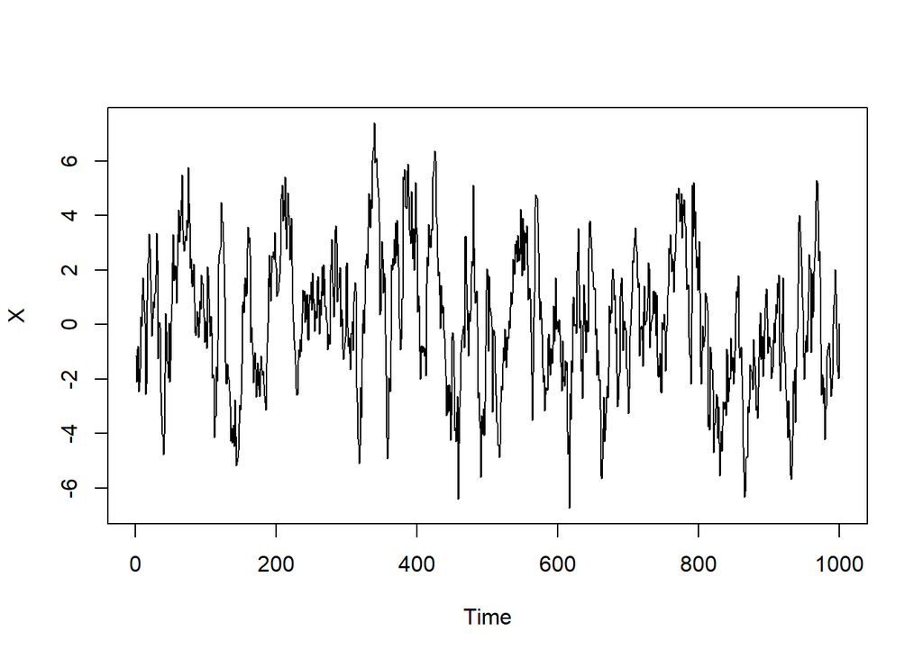

```r
X <- rep(NA,n)
X[1] <- Z[1]
for (j in 2:n) {
   X[j] <- phi*X[j-1]+Z[j]
}
ts.plot(X)
```

### a)

We plot the `acf` confidence bands:

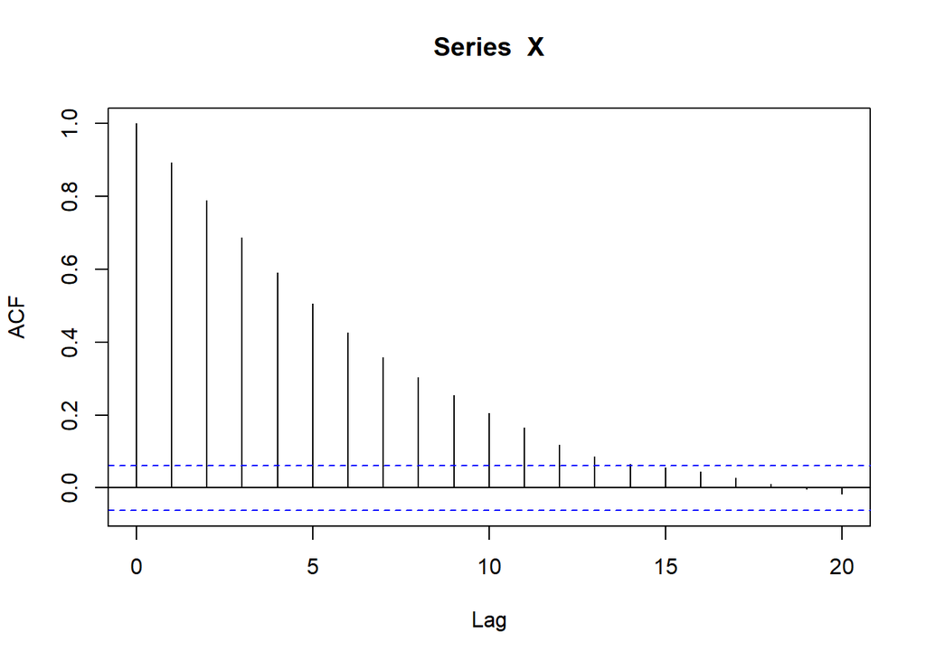

```r
acf(X, lag.max = desiredlag, plot = T)
```

```r
#acf(X, lag.max = desiredlag, plot = F)
```

Assuming the requirement to sample from $X,$ and not from $Z$ which would be more in line with the theoretical foundation for permutations of data, which are in and of themselves understood here, to be a random reordering of all data points. We may create a matrix containing $10^3$ rows, each a permutation of the $X$ data as such:

```r
m <- 10^3
M <- matrix(NA, nrow = m, ncol = n)
for (i in 1:m) {
   M[i,] <- sample(X)
}
```

For each of these ‘permuted’ data sets, we will use `acf` to calculate sample autocorrelations for lags once again up to `desiredlag =`$20,$ and then the $95\%$ quantiles for each of the lags:

```r
AutM <- apply(M,1,acf,lag.max=desiredlag, plot = F)
temp <- matrix(NA,nrow = m, ncol = desiredlag+1)
for (i in 1:1000) {
   temp[i,] <- AutM[[i]][[1]]
}
quanties <- apply(temp,2,quantile, prob=c(0.025,0.975))
```

```r
#ggplot(quanties) + geom_line(aes())
#groupby?
```

### b)

We note that our AR(1) model is causal as $\mathopen{}\left|{\phi}\right|\mathclose{}<1.$ Following example 4.25, we will need to calculate the sample autocovariance function:
$$\begin{equation*}
\gamma_{n,X}\mathopen{}\left({h}\right)\mathclose{}:=\frac{1}{n}\sum_{t=1}^{n-h}{\mathopen{}\left({X_t-\overline{X}_n}\right)\mathclose{}\mathopen{}\left({X_{t+h}-\overline{X}_n}\right)\mathclose{}}
\end{equation*}$$
and autocorrelation function:
$$\begin{equation*}
\rho_{n,X}\mathopen{}\left({h}\right)\mathclose{}:=\frac{\gamma_{n,X}\mathopen{}\left({h}\right)\mathclose{}}{\gamma_{n,X}\mathopen{}\left({0}\right)\mathclose{}}
\end{equation*}$$
Note thus in particular that we may calculate $\gamma_{n,X}\mathopen{}\left({1}\right)\mathclose{},\,\gamma_{n,X}\mathopen{}\left({0}\right)\mathclose{}$ in with the following homemade function

```r
gammaf <- function(X,h) {
   n <- length(X)
   gamt <- 0
   for (t in 1:(n-h)) {
      tempt <- (X[t]-mean(X))*(X[t+h]-mean(X))
      gamt <- gamt + tempt
   }
   1/n*gamt
}
```

Yielding

```r
gammaf(X,1)
```

```
## [1] 5.640264
```

```r
gammaf(X,0)
```

```
## [1] 6.317588
```

Such that for

$$\hat{\phi}_n=\frac{\gamma_{n,X}\mathopen{}\left({1}\right)\mathclose{}}{\gamma_{n,X}\mathopen{}\left({0}\right)\mathclose{}}\equiv\rho_{n,X}\mathopen{}\left({1}\right)\mathclose{}$$
$$\hat{\sigma}_n^2=\gamma_{n,X}\mathopen{}\left({0}\right)\mathclose{}\mathopen{}\left({1-\rho_{n,X}^2\mathopen{}\left({1}\right)\mathclose{}}\right)\mathclose{}$$

```r
(rho1 <- gammaf(X,1)/gammaf(X,0))
```

```
## [1] 0.8927876
```

```r
(phih <- rho1)
```

```
## [1] 0.8927876
```

```r
(sigmah2 <- gammaf(X,0)*(1-rho1^2))
```

```
## [1] 1.28203
```

Let $\nu=10$ be the degrees of freedom of our student-t distributed random noise $Z_t.$ As is surmised on page 47-48 in the lecture notes, in dealing with a causal AR(1) process driven by iid noise $Z_t$ with variance $\sigma^2=\frac{\nu}{\nu-2}=\frac{10}{8}=\frac{5}{4},$ we have asymptotic normality of $\hat\phi$ with corresponding asymptotic mean $\phi$ and asymptotic variance $\frac{\sigma^2\Gamma_p^{-1}}{n}$ i.e.
$$\hat\phi_n\overset{\textit{as}}{\sim}\mathcal{N}\mathopen{}\left({{\phi},{\frac{\sigma^2\Gamma_{p=1}^{-1}}{n}}}\right)\mathclose{}$$
or equivalently
$$\sqrt{n}\mathopen{}\left({\hat\phi-\phi}\right)\mathclose{}\overset{\textit{d}}{\rightarrow}\mathcal{N}\mathopen{}\left({{0},{\sigma^2\Gamma_{1}^{-1}}}\right)\mathclose{}.$$
With this we may for our fixed $n=1000$ determine that $\mathopen{}\left({\phi - \frac{1.96}{\sqrt{n}}\sqrt{\sigma^2\Gamma_1^{-1}},\,\phi + \frac{1.96}{\sqrt{n}}\sqrt{\sigma^2\Gamma_1^{-1}}}\right)\mathclose{}$ will be an asymptotic $95\%$ confidence interval for $\phi.$ Estimating $\Gamma_1$ via the sample autocovariance function, we find:
$$\tilde\Gamma_1:=\gamma_{n,X}\mathopen{}\left({1-1}\right)\mathclose{}=\gamma_{n,X}\mathopen{}\left({0}\right)\mathclose{}=6.3175881$$
such that
$$\tilde\Gamma_1^{-1}=\frac{1}{\tilde\Gamma_1}=0.1582883\neq0$$
such that we may rewrite the confidence bands as
$$\mathopen{}\left({\phi -
\frac{1.96}{\sqrt{n}}\sqrt{\sigma^20.1582883},\,\phi +
\frac{1.96}{\sqrt{n}}\sqrt{\sigma^20.1582883}}\right)\mathclose{}$$
Inserting the other estimates and $n=1000$ we get
$$\begin{equation*}
\mathopen{}\left({\hat\phi -
\frac{1.96}{\sqrt{10^3}}\sqrt{\hat\sigma^20.1582883},\,\hat\phi +
\frac{1.96}{\sqrt{10^3}}\sqrt{\hat\sigma^20.1582883}}\right)\mathclose{}\\
=\mathopen{}\left({0.8927876 -
\frac{1.96}{\sqrt{10^3}}\sqrt{0.2029302},\,0.8927876 +
\frac{1.96}{\sqrt{10^3}}\sqrt{0.2029302}}\right)\mathclose{}\\
=\mathopen{}\left({0.8648667,0.9207085}\right)\mathclose{}
\end{equation*}$$

### c)

#### i+ii)

We calculate the residuals:

```r
Zh <- rep(NA,n)
Zh[1] <- X[1]
for (j in 2:n) {
   Zh[j] <- X[j]+phih*X[j-1]
}
```

We do a reordering of these in the requested fashion using `sample`:

```r
Zhs<-sample(Zh)
```

We define a new sample:

```r
Xhs <- rep(NA,n)
Xhs[1] <- Zhs[1]
for (j in 2:n) {
   Xhs[j] <- phih*Xhs[j-1]+Zhs[j]
}
```

#### iii)

##### part1)

As in b)

```r
(hsrho1 <- gammaf(Xhs,1)/gammaf(Xhs,0))
```

```
## [1] 0.8541978
```

```r
(hsphih <- hsrho1)
```

```
## [1] 0.8541978
```

##### part2)

We repeat the tasks done in the previous exercises by writing a function to do so

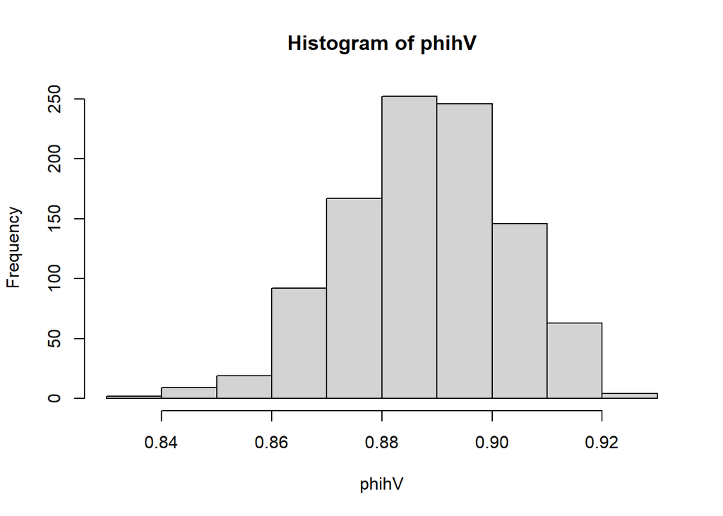

```r
boots <- function(Zh,n) { #Simulating the Bootstrap data
   q <- length(Zh)
   XhsM <- matrix(NA,nrow=n,ncol=q)
   for (i in 1:n) {
      Zhsi <- sample(Zh)
      XhsM[i,1] <- Zhsi[1]
      for (j in 2:q) {
        XhsM[i,j] <- phih*XhsM[i,j-1]+Zhsi[j]
      }
   }
   XhsM
}

dat <- boots(Zh,1000)
YW <- function(Zh,n) { #Calculating the YW's
   q <- length(Zh)
   dat <- boots(Zh,n)
   phihV <- rep(NA,n)
   for (i in 1:n) {
      phihV[i] <- gammaf(dat[i,],1)/gammaf(dat[i,],0)
   }
   phihV
}
phihV <- YW(Zh,n)
hist(phihV)
```

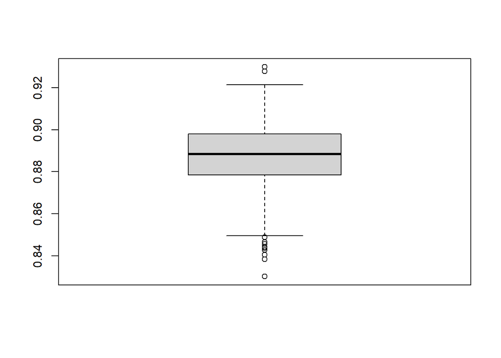

```r
boxplot(phihV)
```

```r
quantile(phihV, c(0.025, 0.975))
```

```
##      2.5%     97.5%
## 0.8587749 0.9149991
```

Comparing this confidence interval to the asymptotic one achieved in b):

```r
rbind(quantile(phihV, c(0.025, 0.975)), c(phih - 1.96/(sqrt(n))*sqrt(sigmah2*1/gammaf(X,0)),phih + 1.96/(sqrt(n))*sqrt(sigmah2*1/gammaf(X,0))))
```

```
##           2.5%     97.5%
## [1,] 0.8587749 0.9149991
## [2,] 0.8648667 0.9207085
```

we notice a great similarity, though the asymptotic confidence interval seems shifted approximately $\cong0.007$ in comparison to the bootstrap interval.

## Exercise 2

We may import the data

```r
Data <- read_csv("Data.csv",col_types =
                       cols(col_date(),
                            col_double(),
                            col_double(),
                            col_double(),
                            col_double(),
                            col_double(),
                            col_integer()))
head(Data, 10)
```

```
## # A tibble: 10 × 7
##    Date        Open  High   Low Close `Adj Close` Volume
##    <date>     <dbl> <dbl> <dbl> <dbl>       <dbl>  <int>
##  1 1990-03-01 1796. 1796. 1796. 1796.       1796.      0
##  2 1990-03-02 1805. 1805. 1805. 1805.       1805.      0
##  3 1990-03-05 1838. 1838. 1838. 1838.       1838.      0
##  4 1990-03-06 1820. 1820. 1820. 1820.       1820.      0
##  5 1990-03-07 1842. 1842. 1842. 1842.       1842.      0
##  6 1990-03-08 1862. 1862. 1862. 1862.       1862.      0
##  7 1990-03-09 1859. 1859. 1859. 1859.       1859.      0
##  8 1990-03-12 1844. 1844. 1844. 1844.       1844.      0
##  9 1990-03-13 1867. 1867. 1867. 1867.       1867.      0
## 10 1990-03-14 1877. 1877. 1877. 1877.       1877.      0
```

We may create a yearly data set, and filter for data after 2000 and remove `NA`’s

```r
Data_new <- Data %>% filter(year(Date)>=2000) %>%  mutate(returns = (Close - lag(Close))/lag(Close),
                                                  logreturns = log(1+returns),
                                                  abslogreturn = abs(logreturns),
                                                  absdiff = abs(returns - logreturns))
Data_new_clean <- Data_new %>% na.omit()
Data_new_new <- Data_new %>% group_by(year(Date)) %>% rename('year' = 'year(Date)') %>% summarise(mean = mean(logreturns, na.rm = T), var = var(logreturns, na.rm = T), absmean = mean(abs(logreturns), na.rm = T), absvar = var(abs(logreturns), na.rm = T))
```

We plot these:

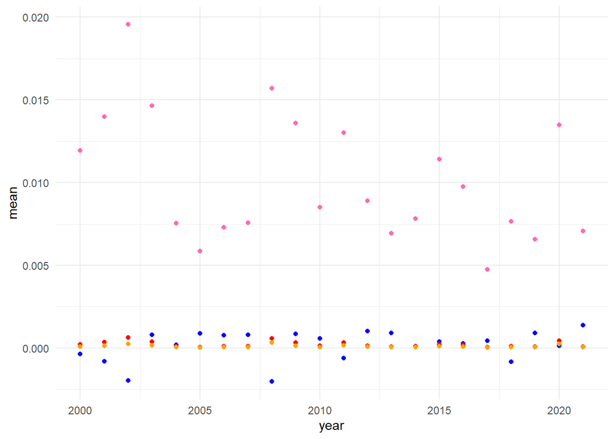

```r
ggplot(Data_new_new) + geom_point(aes(x=year, y=mean), colour = 'blue') + geom_point(aes(x=year, y=var), colour = 'red') + geom_point(aes(x=year, y=absmean), colour = 'hotpink') + geom_point(aes(x=year, y=absvar), colour = 'orange')
```

## Exercise 3

### a)

We might plot the absolute differences:

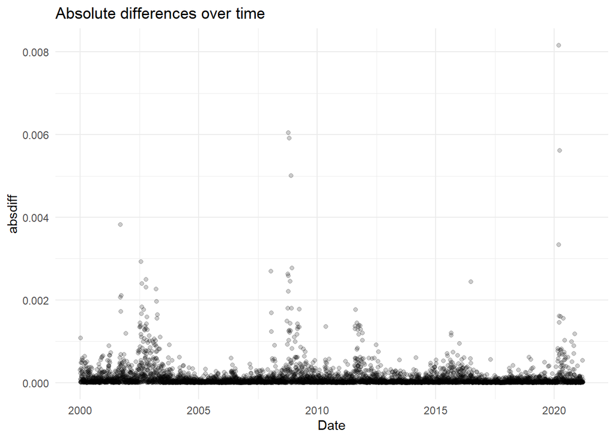

```r
ggplot(Data_new_clean, aes(x=Date, y=absdiff)) + geom_point(alpha = 0.2) + ggtitle("Absolute differences over time")
```

and calculate the maximum of the absolute difference between returns and logreturns:

```r
max(Data_new_clean$absdiff)
```

```
## [1] 0.008162438
```

### b)

We note that the dataset `Data_new_clean` has `nrow(Data_new_clean) =5353` data points, such that 10% of the sample size of the log return time series will be of the size `floor(nrow(Data_new_clean)/10) =535`. We may use `acf` to calculate this many lags for the sample autocorrelation function for the log-return time series, its absolute value, and its square:

```r
autocorLogRet <- acf(Data_new_clean$logreturns, lag.max = floor(nrow(Data_new_clean)/10), plot=F)
autocorLogRetAbs <- acf(Data_new_clean$abslogreturn, lag.max = floor(nrow(Data_new_clean)/10), plot=F)
autocorLogRetSquared <- acf((Data_new_clean$logreturns)^2, lag.max = floor(nrow(Data_new_clean)/10), plot=F)
```

We may also choose to plot each of these:

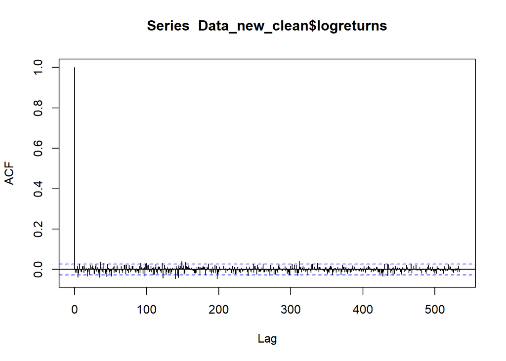

```r
acf(Data_new_clean$logreturns, lag.max = floor(nrow(Data_new_clean)/10), plot=T)
```

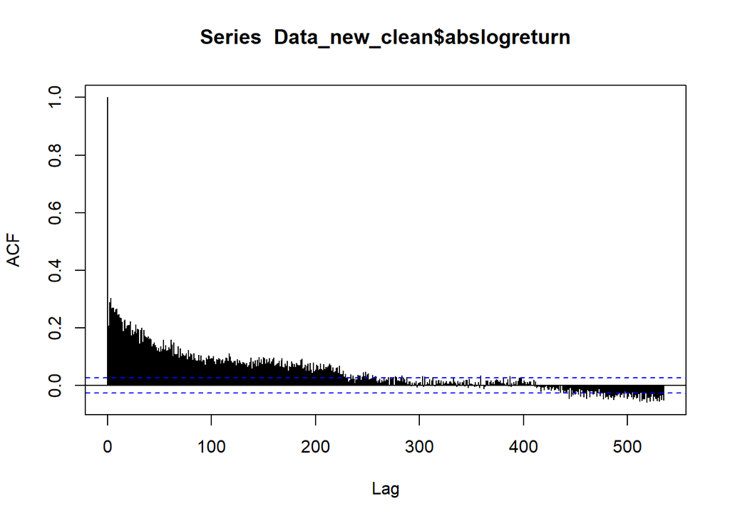

```r
acf(Data_new_clean$abslogreturn, lag.max = floor(nrow(Data_new_clean)/10), plot=T)
```

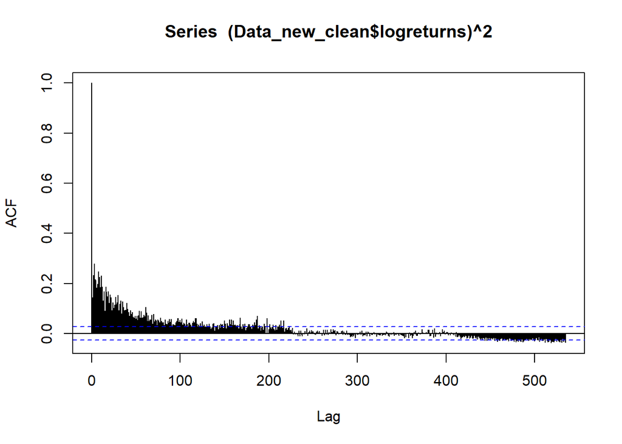

```r
acf((Data_new_clean$logreturns)^2, lag.max = floor(nrow(Data_new_clean)/10), plot=T)
```

### c)

We will fit the AR model using `ar.yw`

```r
Data_logreturn <- Data_new_clean[,9][[1]]
head(Data_logreturn)
```

```
## [1] -0.024564608 -0.012969888 -0.004184320  0.046182439  0.021094463
## [6] -0.004960651
```

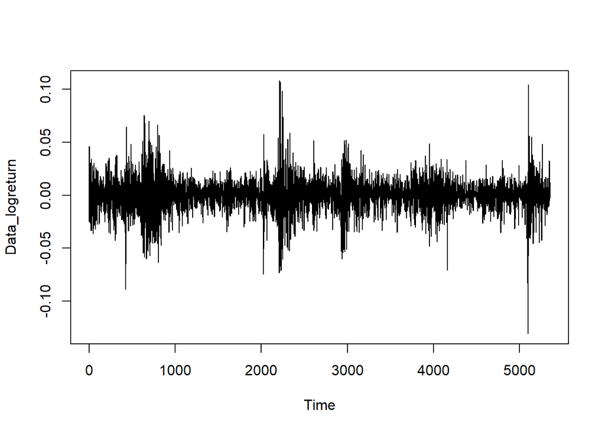

```r
ts.plot(Data_logreturn)
```

```r
modellr <- ar.yw(Data_logreturn, aic = T)
```

We may see a summary of the model:

```r
print(modellr)
```

```
##
## Call:
## ar.yw.default(x = Data_logreturn, aic = T)
##
## Coefficients:
##       1        2        3        4        5        6        7
## -0.0132  -0.0030  -0.0145   0.0156  -0.0385  -0.0183   0.0289
##
## Order selected 7  sigma^2 estimated as  0.0002197
```

```r
summary(modellr)
```

```
##              Length Class  Mode
## order           1   -none- numeric
## ar              7   -none- numeric
## var.pred        1   -none- numeric
## x.mean          1   -none- numeric
## aic            38   -none- numeric
## n.used          1   -none- numeric
## n.obs           1   -none- numeric
## order.max       1   -none- numeric
## partialacf     37   -none- numeric
## resid        5353   -none- numeric
## method          1   -none- character
## series          1   -none- character
## frequency       1   -none- numeric
## call            3   -none- call
## asy.var.coef   49   -none- numeric
```

### d)

We may simulate based on the built up model:

```r
modellr$ar
```

```
## [1] -0.013222942 -0.003024756 -0.014527039  0.015641328 -0.038478367
## [6] -0.018285413  0.028921894
```

```r
model3d <- arima.sim(model = list(ar = modellr$ar), n = length(Data_logreturn), rand.gen = function(n,...) rt(n,df=4))
summary(model3d)
```

```
##       Min.    1st Qu.     Median       Mean    3rd Qu.       Max.
## -13.198054  -0.729220  -0.010417  -0.007745   0.730539  10.396367
```

We may plot the series, together with the original log-returns:

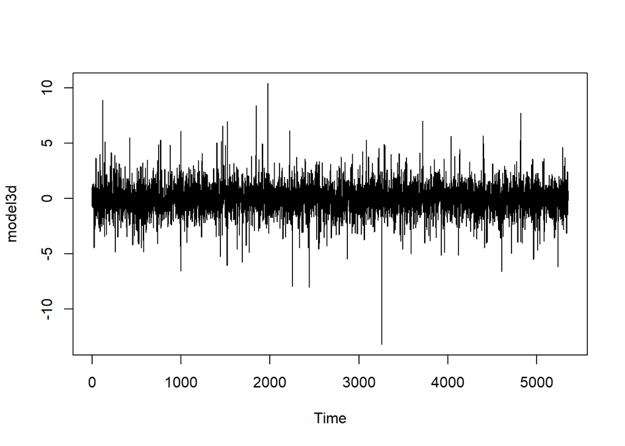

```r
plot(model3d)
```

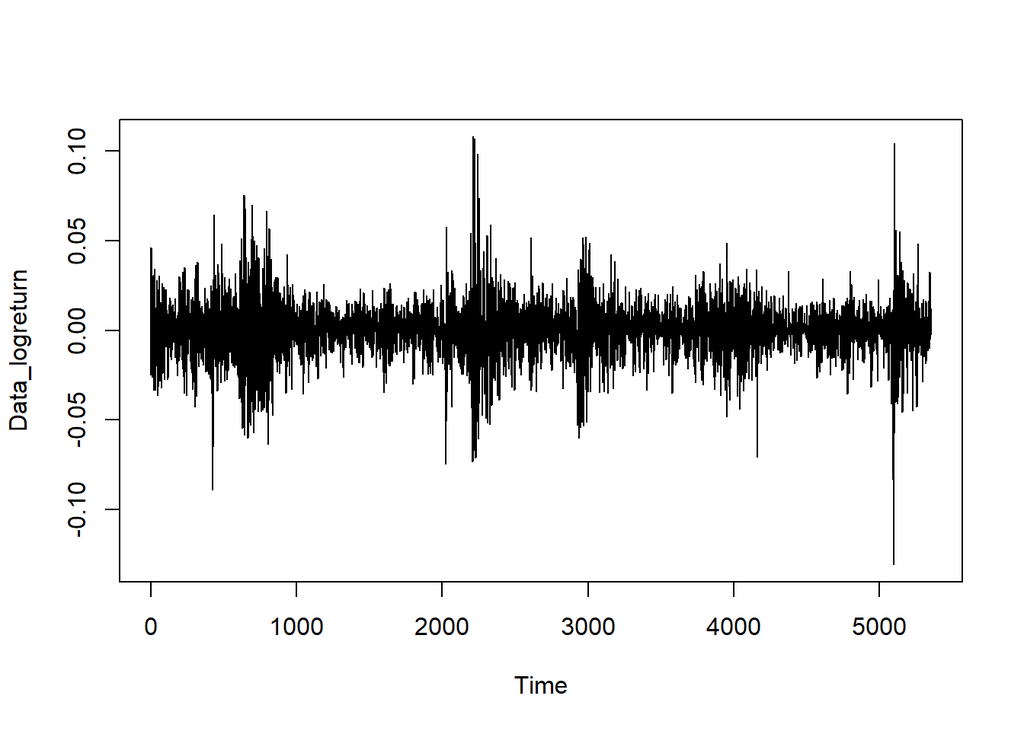

```r
ts.plot(Data_logreturn)
```

and the requested autocorrelations:

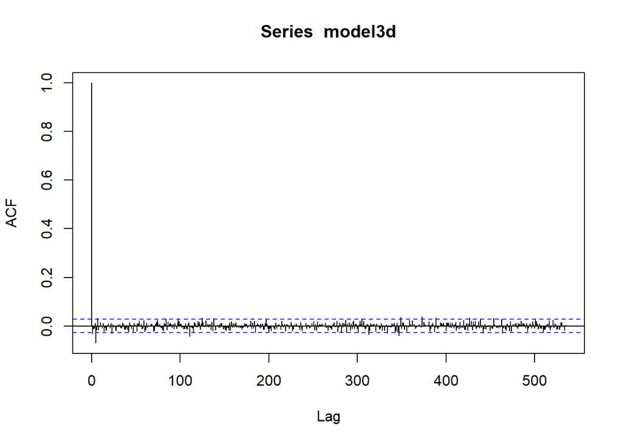

```r
acf(model3d,lag.max = floor(nrow(Data_new_clean)/10), plot=T)
```

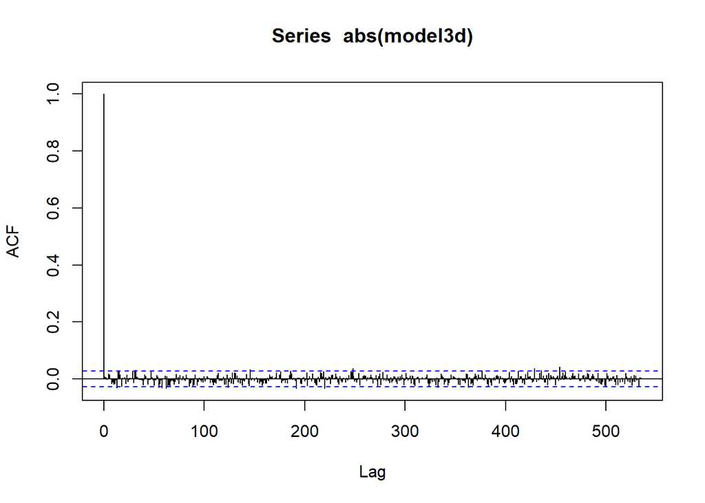

```r
acf(abs(model3d), lag.max = floor(nrow(Data_new_clean)/10), plot=T)
```

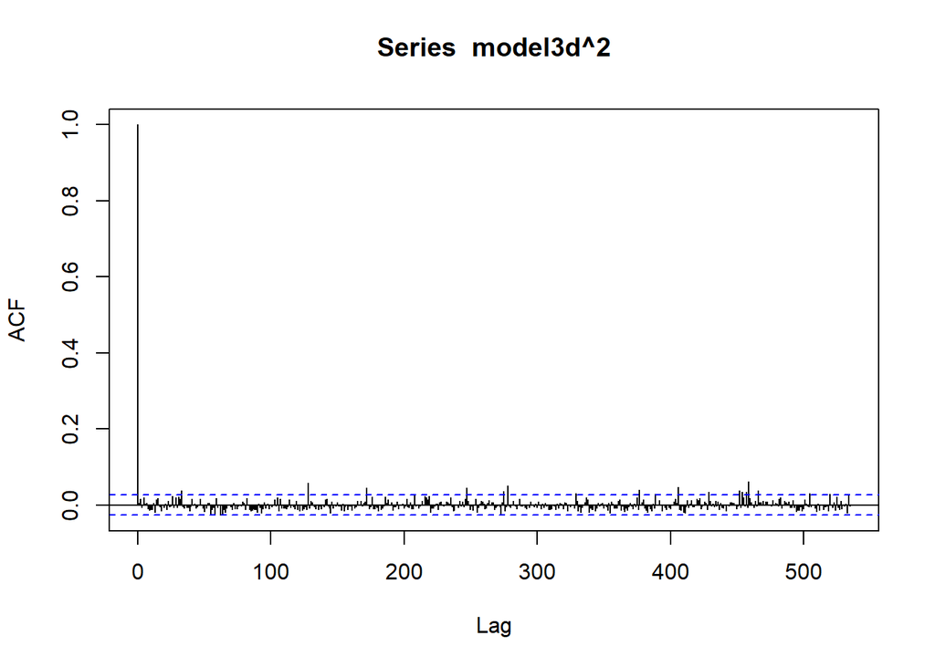

```r
acf(model3d^2, lag.max = floor(nrow(Data_new_clean)/10), plot=T)
```

We might note that comparing the plot of `model3d` to the log-return series, a striking difference appears, in that the model seems to attain values orders of magnitude higher, than there is in the original log-returns time series:

We may also note that while the autocorrelation function of the untransformed `model3d` looks rather similar to that of untransformed log-return series, the transformations appear dissimilar, possibly hinting at another problem. It seems that `model3d` as a model does not perform adequately in these circumstances, such that a different model, or a different choice of noise term might be needed.

## Exercise 4

### a)

Noting that $\rho_X\mathopen{}\left({h}\right)\mathclose{}=\phi^{\mathopen{}\left|{h}\right|\mathclose{}}$ we may compute
$$\begin{align}
w_{hh}&=\sum_{k=1}^{\infty}{\mathopen{}\left({\rho_X\mathopen{}\left({k+h}\right)\mathclose{}+\rho_X\mathopen{}\left({k-h}\right)\mathclose{}-2\rho_X\mathopen{}\left({h}\right)\mathclose{}\rho_X\mathopen{}\left({k}\right)\mathclose{}}\right)\mathclose{}^2}\\
&=\sum_{k=1}^{\infty}{\mathopen{}\left({\phi^{\mathopen{}\left|{k+h}\right|\mathclose{}}+\phi^{\mathopen{}\left|{k-h}\right|\mathclose{}}-\phi^{\mathopen{}\left|{k}\right|\mathclose{}}\phi^{\mathopen{}\left|{h}\right|\mathclose{}}}\right)\mathclose{}^2}\\
&=\sum_{k=1}^{\infty}{\mathopen{}\left({\phi^{\mathopen{}\left|{k-h}\right|\mathclose{}}-\phi^{\mathopen{}\left|{k+h}\right|\mathclose{}}}\right)\mathclose{}^2}\\
&=\sum_{k=1}^{h}{\mathopen{}\left({\phi^{h-k}-\phi^{k+h}}\right)\mathclose{}^2}+\sum_{k=h+1}^{\infty}{\mathopen{}\left({\phi^{k-h}-\phi^{k+h}}\right)\mathclose{}^2}\\
&=\sum_{k=1}^{h}{\phi^{2h}\mathopen{}\left({\phi^{-k}-\phi^{k}}\right)\mathclose{}^2}+\sum_{k=h+1}^{\infty}{\phi^{2k}\mathopen{}\left({\phi^{-h}-\phi^{h}}\right)\mathclose{}^2}\\
&=\phi^{2h}\sum_{k=1}^{h}{\mathopen{}\left({\phi^{-k}-\phi^{k}}\right)\mathclose{}^2}+\mathopen{}\left({\phi^{-h}-\phi^{h}}\right)\mathclose{}^2\sum_{k=h+1}^{\infty}{\phi^{2k}}\\
&=-\frac{\phi^{2h}\mathopen{}\left({1+2h - \phi^2-2h \phi^2 -
\phi^{-2h}+\phi^{2+2h}}\right)\mathclose{}}{1-\phi^2}+\frac{\phi^{2h+2}\mathopen{}\left({\phi^{-h}-\phi^h}\right)\mathclose{}^2}{1-\phi^2}
\end{align}$$
such that for $0<\phi<1$ we may conclude that for $h\rightarrow\infty$
$$\begin{align}
w_{hh}\rightarrow\frac{1}{1-\phi^2}+\frac{\phi^2}{1-\phi^2}.
\end{align}$$

### b)

We will simulate a size $200$ sample from the AR(1) process as follows:

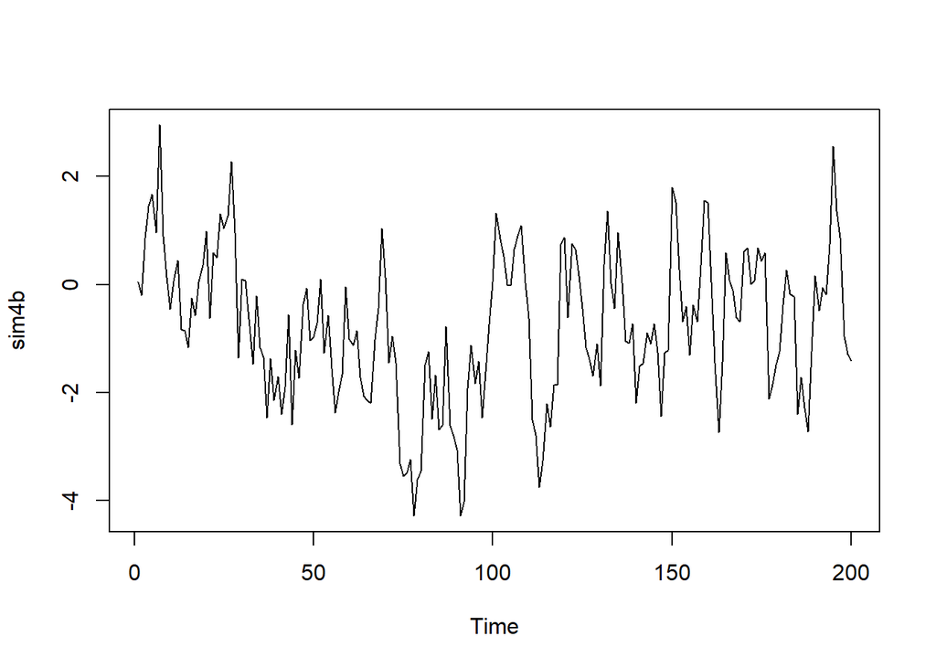

```r
sim4b <- arima.sim(model = list(ar = 0.8), n=200)
ts.plot(sim4b)
```

We may draw the sample auotcorrelations, along with the confidence band for the iid white noise for a $25$ lag:

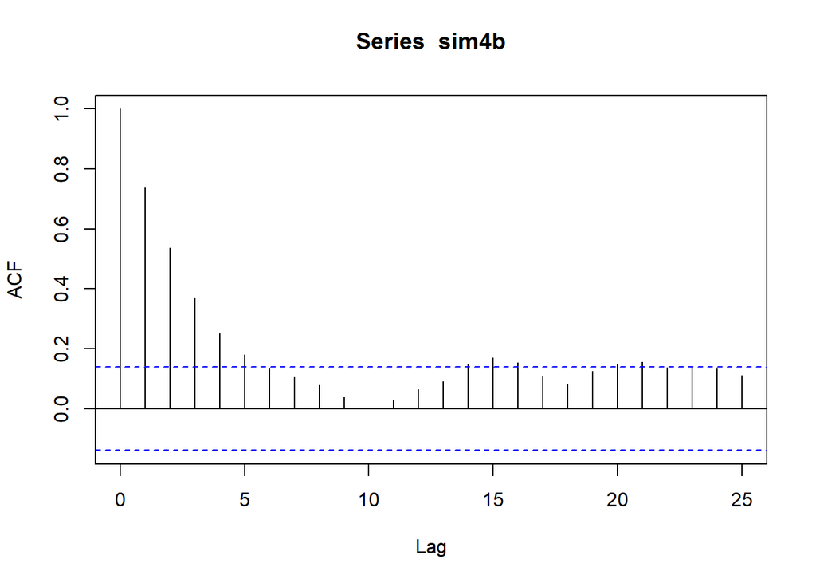

```r
acf(sim4b, lag.max = 25)
```

for each lag up to $25$ we may do the calculation of the $95\%$ asymptotic confidence bands from a)

```r
n4b <- 200
phi4b <- 0.8
rhonX4b <- as.numeric(acf(sim4b, lag.max = 25, plot=F)[[1]])
w <- 1:25
autocorconfp <- 1:25
autocorconfm <- 1:25
for (h in w) {
   w[h] <- -((phi4b^(2*h))*(1+2*h-phi4b^2-2*h*phi4b^2-phi4b^(-2*h)+phi4b^(2+2*h)))/(1-phi4b^2)+(phi4b^(2*h+2)*(phi4b^(-h)-phi4b^h)^2)/(1-phi4b^2)
   autocorconfp[h] <- rhonX4b[h]+qnorm(0.975)*sqrt(w[h]/n4b)
   autocorconfm[h] <- rhonX4b[h]-qnorm(0.975)*sqrt(w[h]/n4b)
}
autocorconf <- rbind(autocorconfp, autocorconfm)
```

We may plot the asymptotic correlation confidence bands together with the previous sample auto correlation function

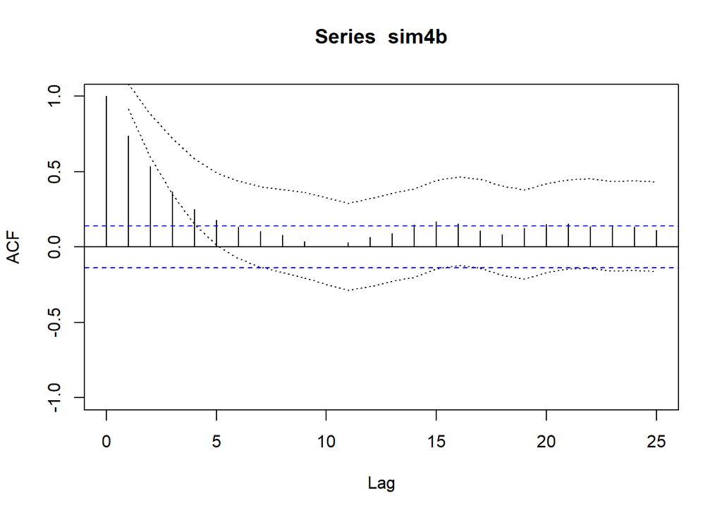

```r
acf(sim4b, lag.max = 25, ylim = c(-1,1));lines(1:25, autocorconfp, lty = 3);lines(1:25, autocorconfm, lty = 3)
```

## Exercise 5

We may import the dataset, convert it to `xts` and calculate last day of each year

```r
ss <- as.xts(sunspots)
ep <- ss %>% endpoints("years")
```

With this, we will aggregate the data averaging over each year:

```r
ssy <- ss %>% period.apply(INDEX = ep, FUN = mean)
```

[output not shown]

```r
head(ssy)
```

```
##              [,1]
## Dec 1749 80.92500
## Dec 1750 83.39167
## Dec 1751 47.65833
## Dec 1752 47.80000
## Dec 1753 30.69167
## Dec 1754 12.21667
```

### a)

We may calculate AIC using the `ar.yw` command:

```r
model5a <- ar.yw(ssy, order.max= 20)
model5a$aic
```

```
##          0          1          2          3          4          5          6
## 422.180447 162.851001  18.446755  18.064145  19.704643  21.684112  17.947992
##          7          8          9         10         11         12         13
##  13.778283   4.123101   0.000000   1.836597   3.759563   5.598154   7.522672
##         14         15         16         17         18         19         20
##   8.578587   9.886723  10.866008  11.055926  12.595664  14.138207  16.136743
```

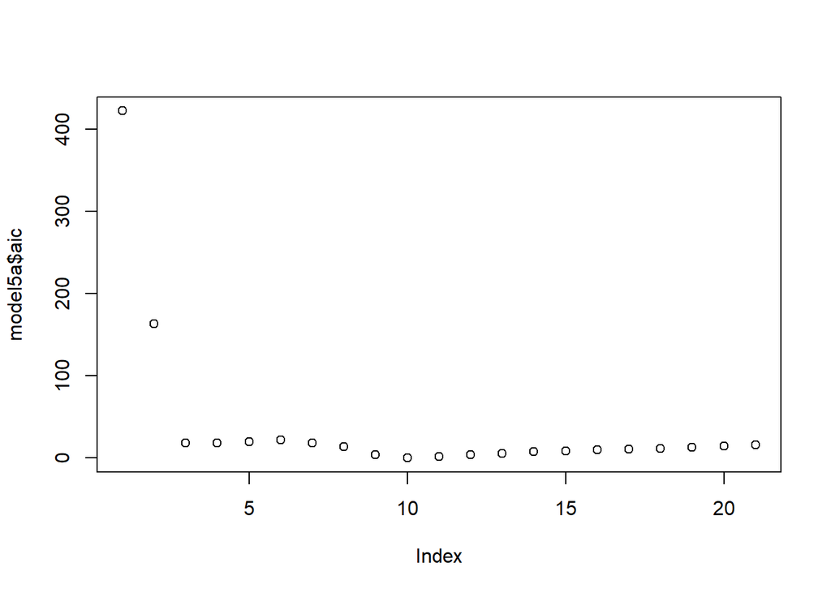

```r
plot(model5a$aic)
```

### b)

We may let `ar.yw` choose the order of the AR model that minimizes the AIC over `ssy`:

```r
model5b <- ar.yw(ssy, aic = T)
print(model5b)
```

```
##
## Call:
## ar.yw.default(x = ssy, aic = T)
##
## Coefficients:
##       1        2        3        4        5        6        7        8
##  1.2187  -0.4644  -0.1339   0.1351  -0.1133   0.0730  -0.0450   0.0189
##       9
##  0.1604
##
## Order selected 9  sigma^2 estimated as  264.2
```

```r
summary(model5b)
```

```
##              Length Class  Mode
## order          1    -none- numeric
## ar             9    -none- numeric
## var.pred       1    -none- numeric
## x.mean         1    -none- numeric
## aic           24    -none- numeric
## n.used         1    -none- numeric
## n.obs          1    -none- numeric
## order.max      1    -none- numeric
## partialacf    23    -none- numeric
## resid        235    -none- numeric
## method         1    -none- character
## series         1    -none- character
## frequency      1    -none- numeric
## call           3    -none- call
## asy.var.coef  81    -none- numeric
```

We may then simulate from the model

```r
simModel5b1 <- arima.sim(model = list(ar = model5b$ar), n = length(ssy))
```

And provide the respective plots:

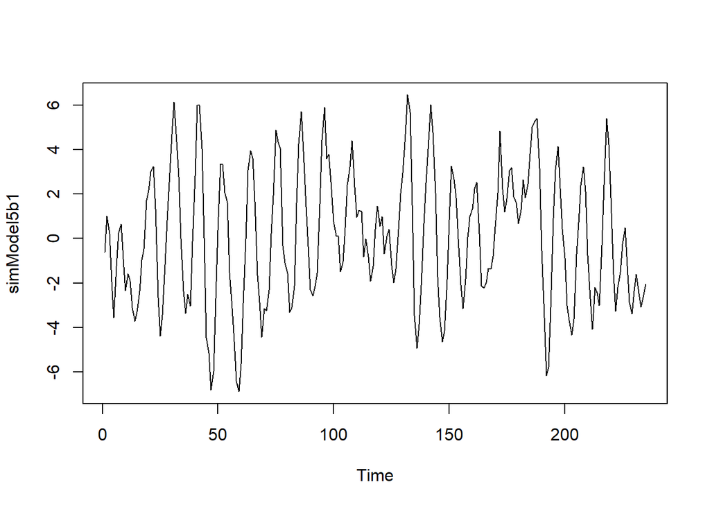

```r
ts.plot(simModel5b1)
```

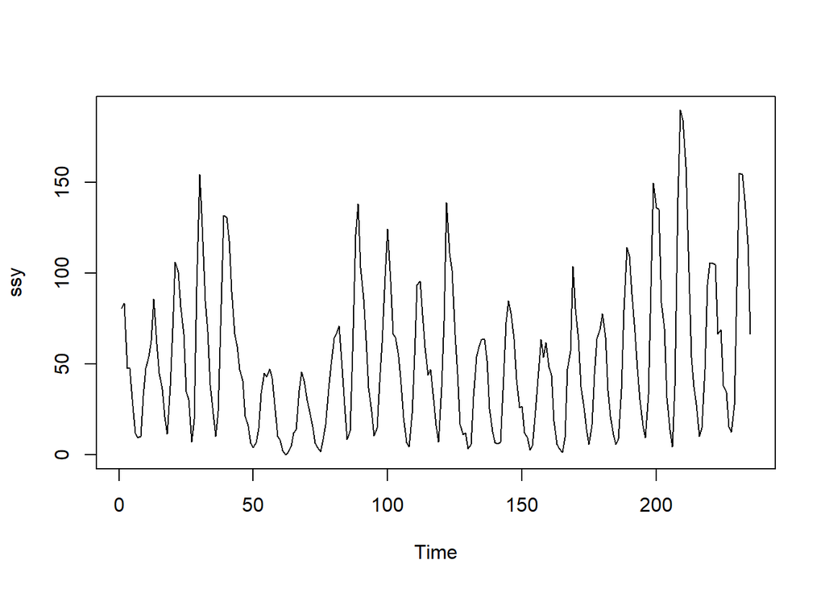

```r
ts.plot(ssy)
```

It seems that the noise terms in the `simModel5b1` that by default are chosen by `arima.sim` to be iid standard normally distributed have one major problem: `simModel5b1` attains the wrong range of values, than required in order to model `ssy`

We will attempt to solve these problems by implementing the suggested solutions to these problems provided. Staying within iid normal noise, we may take a look at the residuals of `model5b` attain their mean and standard deviation, in order to attempt a non-standard normal noise term model

```r
head(model5b$resid,15)
```

```
##  [1]         NA         NA         NA         NA         NA         NA
##  [7]         NA         NA         NA  -7.691004  -9.609204   7.470140
## [13]  21.343604 -22.998983   5.214451
```

```r
mean(model5b$resid, na.rm = T)
```

```
## [1] 0.2039417
```

```r
sd(model5b$resid, na.rm = T)
```

```
## [1] 15.58728
```

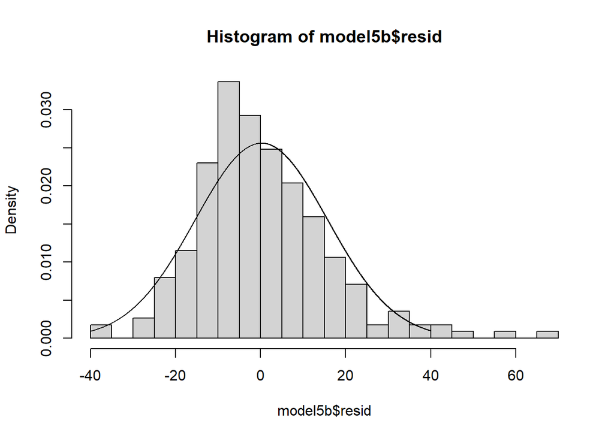

```r
hist(model5b$resid, prob = T, breaks = 20);lines(seq(-40,40,by=0.01), dnorm(seq(-40,40,by=0.01), mean = mean(model5b$resid, na.rm = T), sd = sd(model5b$resid, na.rm = T)))
```

We note from the simple histogram plot above that the fit is adequate, but with resolution lost in the center, probably caused by a few larger values dragging out the summary statistics.

```r
simModel5b2 <- arima.sim(model = list(ar = model5b$ar), n = length(ssy), rand.gen = function(n,...) rnorm(n,mean(model5b$resid, na.rm = T),sd(model5b$resid, na.rm = T)))
```

And provide the respective plots:

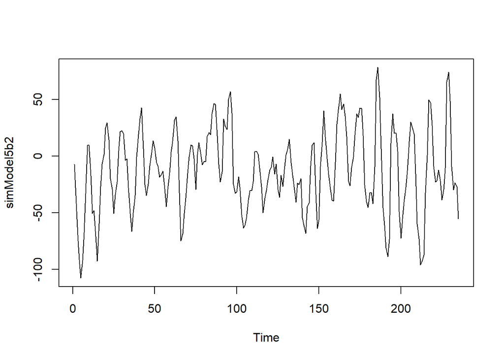

```r
ts.plot(simModel5b2)
```

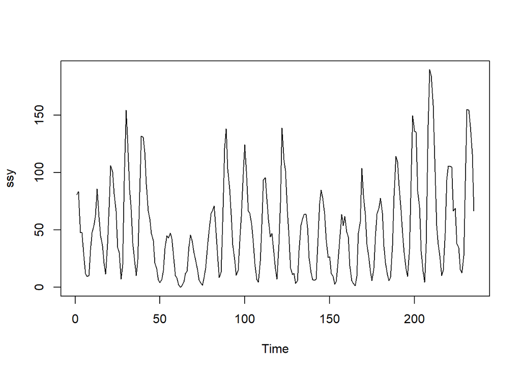

```r
ts.plot(ssy)
```

we see that the variability of `simModel5b2` is now appropriate, though still attaining negative values thus requiring further investigation.

```r
simModel5b2new <- arima.sim(model = list(ar = model5b$ar), n = length(ssy), rand.gen = function(n,...) rcauchy(n,mean(model5b$resid, na.rm = T),sd(model5b$resid, na.rm = T)))
```

Permuting the residuals, we get the following model

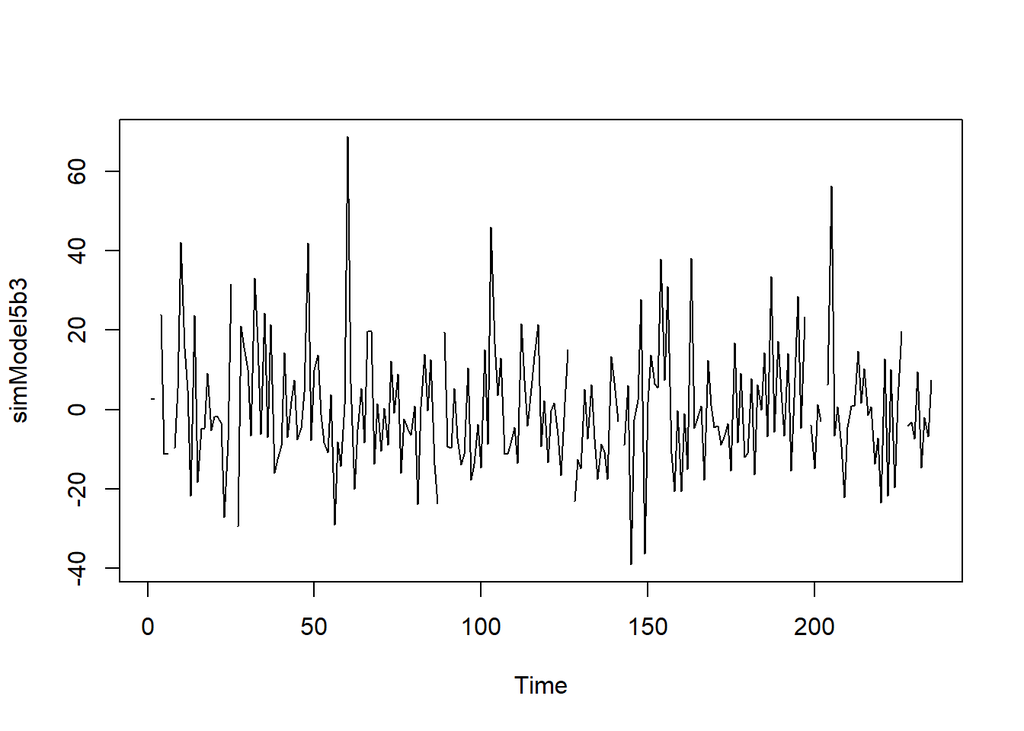

```r
sRes <- sample(model5b$resid)
simModel5b3 <- arima.sim(model = list(ar = model5b$coefficients), n = length(ssy), rand.gen = function(...) sRes)
ts.plot(simModel5b3)
```

### c)

We note that the simulated model attains the same kind of oscillatory autocorrelation behaviour as `ssy`, if not slightly less pronounced.

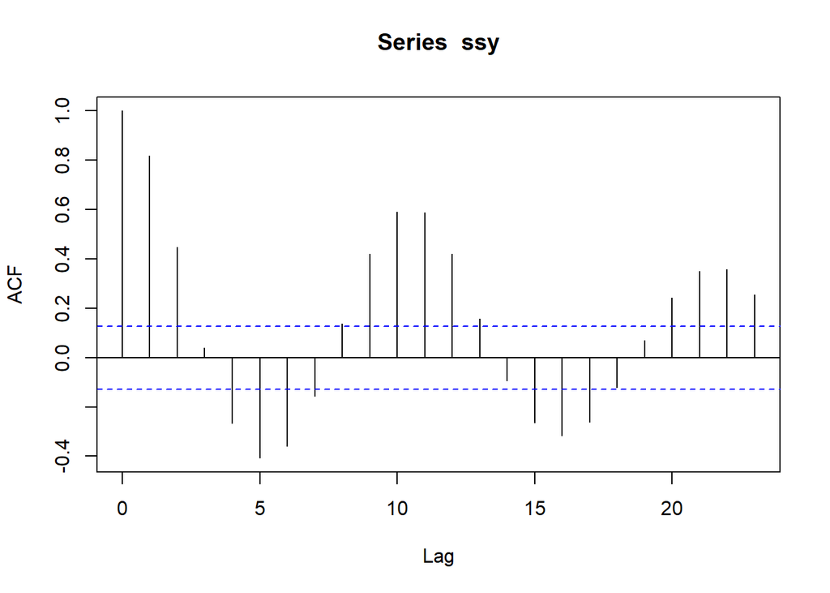

```r
acf(ssy)
```

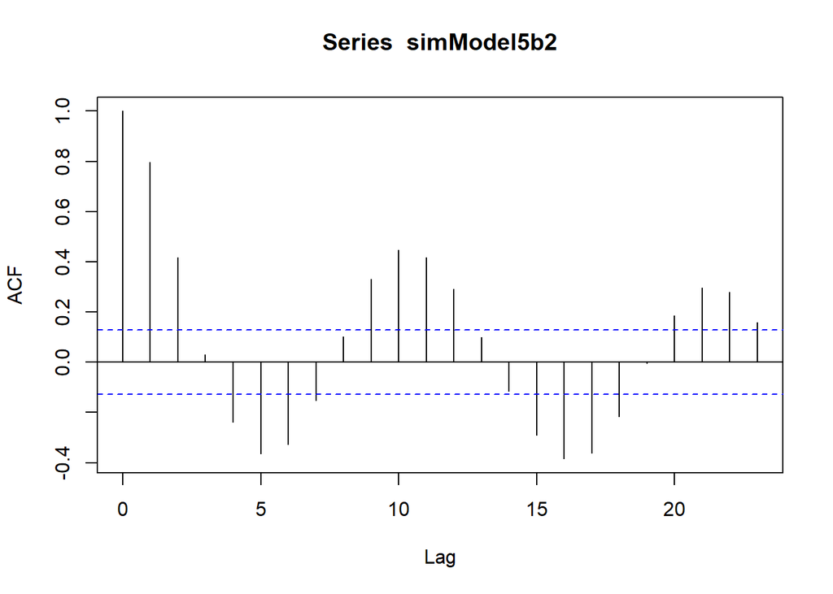

```r
acf(simModel5b2)
```